# cpt prelim analysis

Liz

May 7, 2017

Load necessary libraries:

Import data:

```r
cpt <- read_csv("~/Manduca expts/Summer+Fall 2016/CxPxT/data files/cpt.gr.long.csv",
    col_types = cols(temp = col_factor(levels = c("20",
        "25", "30"))))
cpt$log.mT0<-log(cpt$mass.T0)
cpt$log.mass<-log(cpt$mass)
cpt$log.cnsmp<-log(cpt$tot.cnsmp)
View(cpt)

wide <- read_csv("~/Manduca expts/Summer+Fall 2016/CxPxT/data files/cpt gr wide.csv",
    col_types = cols(temp = col_factor(levels = c("20",
        "25", "30")), treatment = col_factor(levels = c("control",
        "para"))))
View(wide)
```

Subsetting by temperature

```r
#Dividing by temperature

cpt.30<-subset(cpt,temp=="30")

cpt.25<-subset(cpt,temp=="25")

cpt.20<-subset(cpt,temp=="20")
```

## Preliminary Plots

Plot of expected age and mass, all temps and individuals

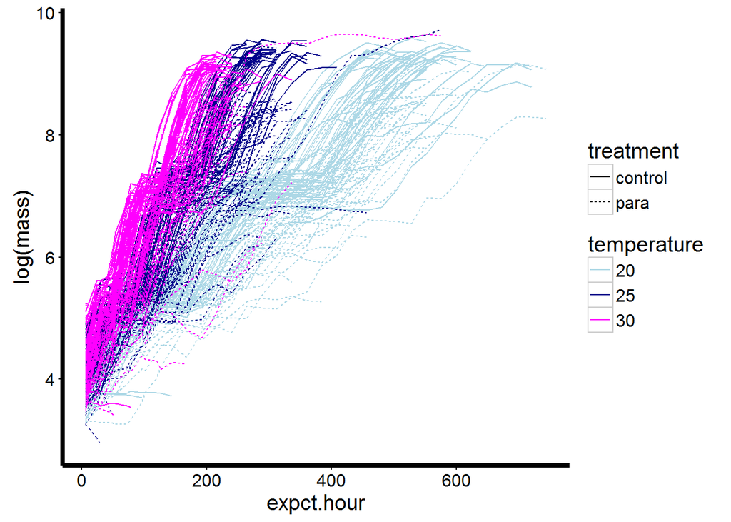

```r
k<- ggplot(cpt, aes(expct.hour, log(mass), group=interaction(bug.id, temp), color=factor(temp)))
k+geom_line(aes(linetype=treatment)
            )+theme_bw(
            )+theme(plot.background = element_blank(),panel.grid.major = element_blank(),
                    panel.grid.minor = element_blank(), panel.border= element_blank(),
                    axis.line.x = element_line(color="black", size = 1.5),
                    axis.line.y = element_line(color="black", size = 1.5),text = element_text(size = 15)
            )+scale_color_manual(values=c( "lightblue","darkblue", "magenta"),
                    guide=guide_legend(title="temperature"))
```

Plot of actual age and mass, all temps and individuals

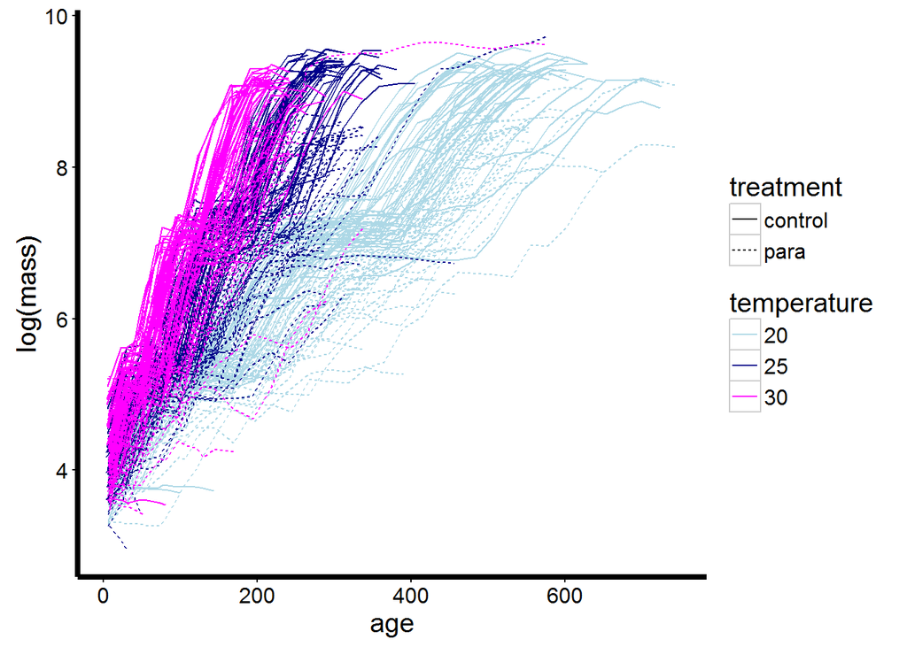

```r
k<- ggplot(cpt, aes(age, log(mass), group=interaction(bug.id, temp), color=factor(temp)))
k+geom_line(aes(linetype=treatment)
)+theme_bw(
)+theme(plot.background = element_blank(),panel.grid.major = element_blank(),
        panel.grid.minor = element_blank(), panel.border= element_blank(),
        axis.line.x = element_line(color="black", size = 1.5),
        axis.line.y = element_line(color="black", size = 1.5),text = element_text(size = 15)
)+scale_color_manual(values=c( "lightblue","darkblue", "magenta"),
                     guide=guide_legend(title="temperature"))
```

Plot of actual age and mass, all individuals, faceted by temp

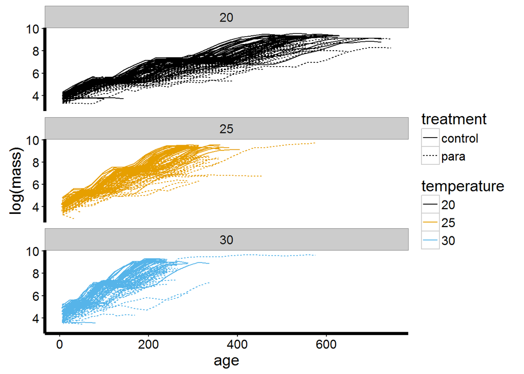

Plotting age and mass for each temperature separately:

30C

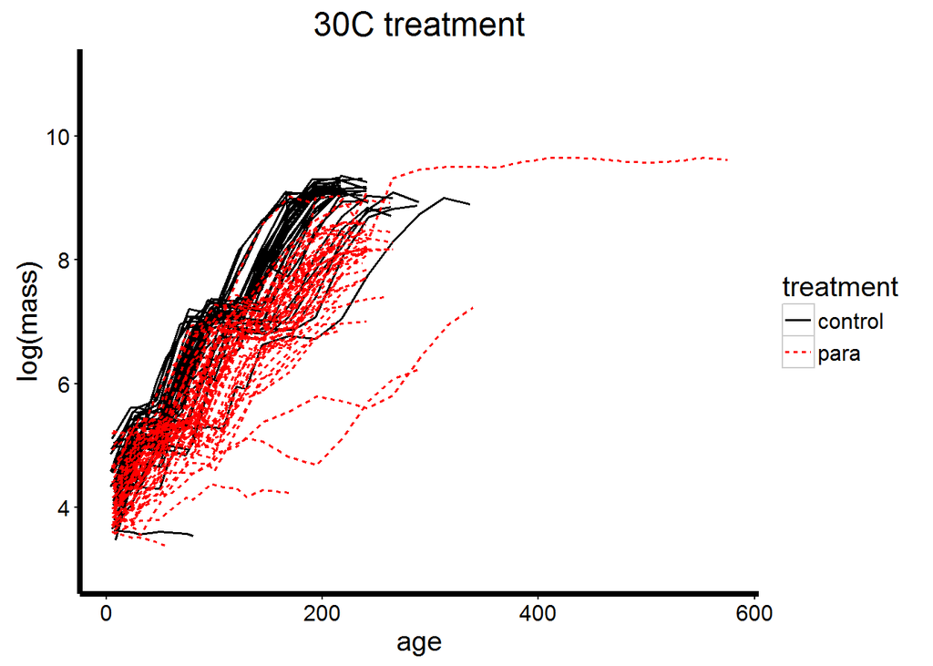

25C

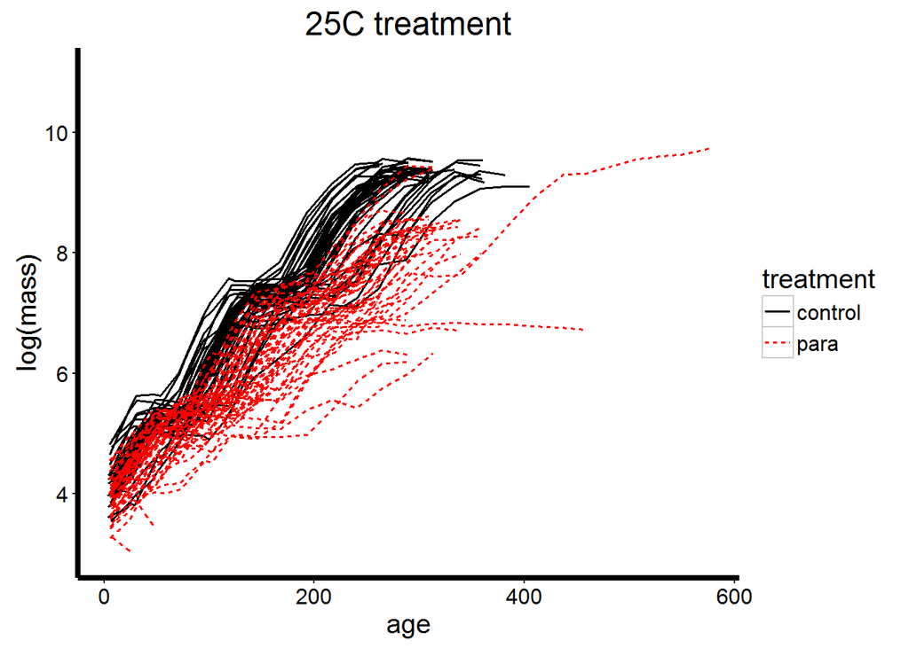

20C

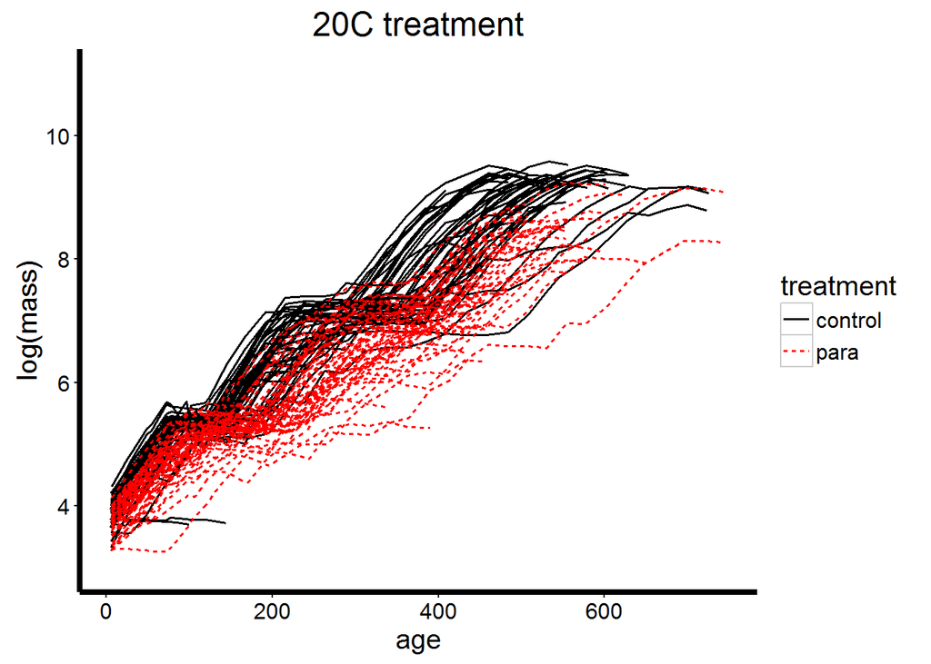

### Plotting mass gained since the start of the 3rd instar

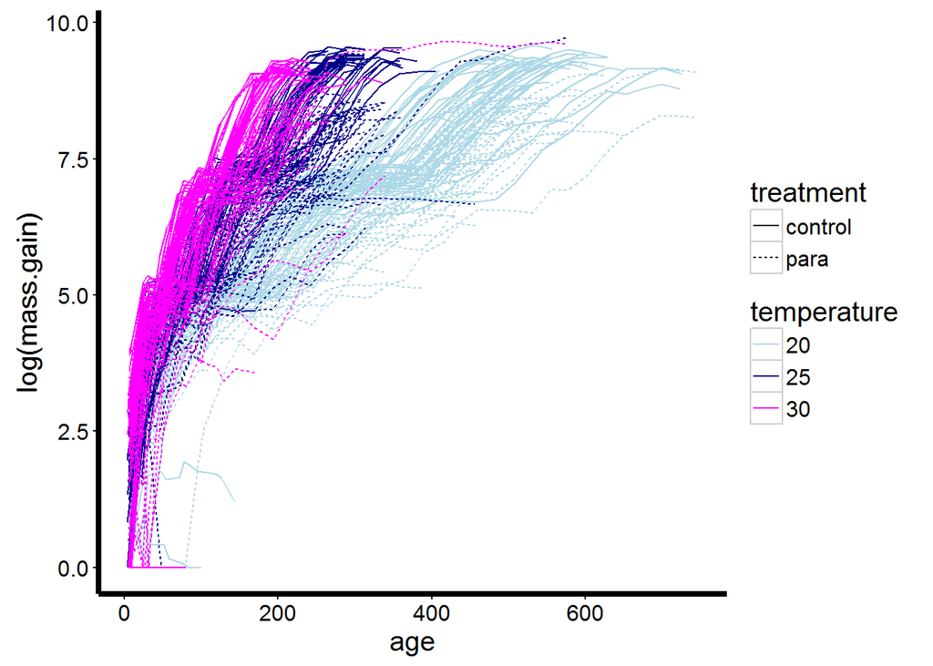

```r
k<- ggplot(cpt, aes(age, log(mass.gain), group=interaction(bug.id, temp), color=factor(temp)))
k+geom_line(aes(linetype=treatment)
)+theme_bw(
)+theme(plot.background = element_blank(),panel.grid.major = element_blank(),
        panel.grid.minor = element_blank(), panel.border= element_blank(),
        axis.line.x = element_line(color="black", size = 1.5),
        axis.line.y = element_line(color="black", size = 1.5),text = element_text(size = 15)
)+scale_color_manual(values=c( "lightblue","darkblue", "magenta"),
                     guide=guide_legend(title="temperature"))
```

Plotting age and mass.gain for each temperature separately:

30C

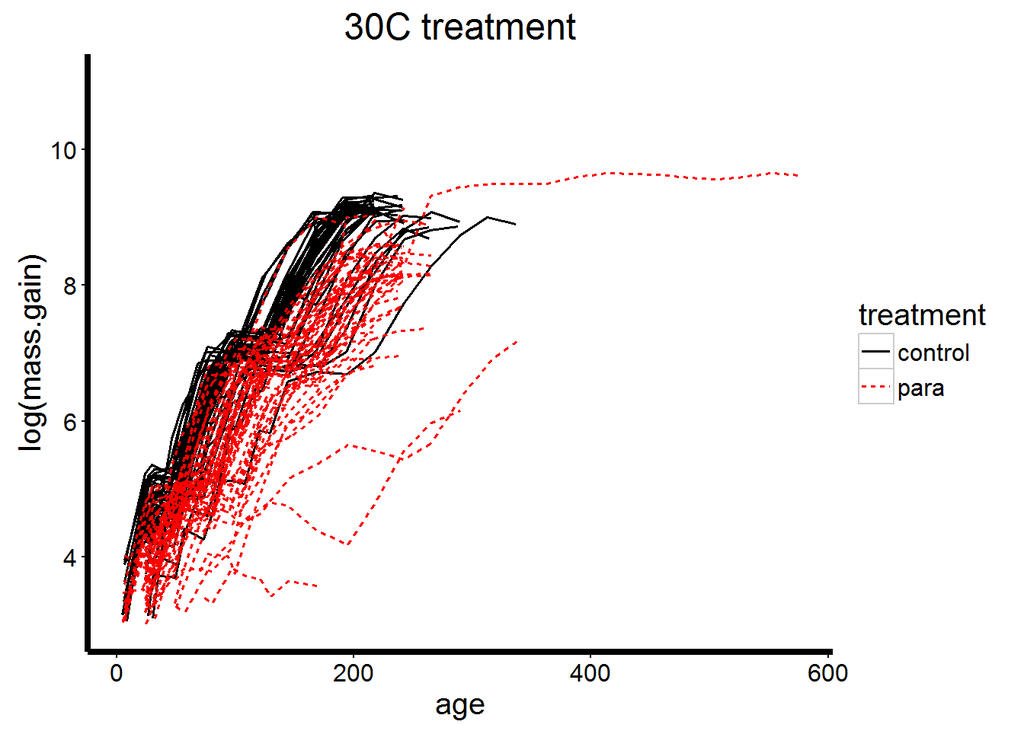

25C

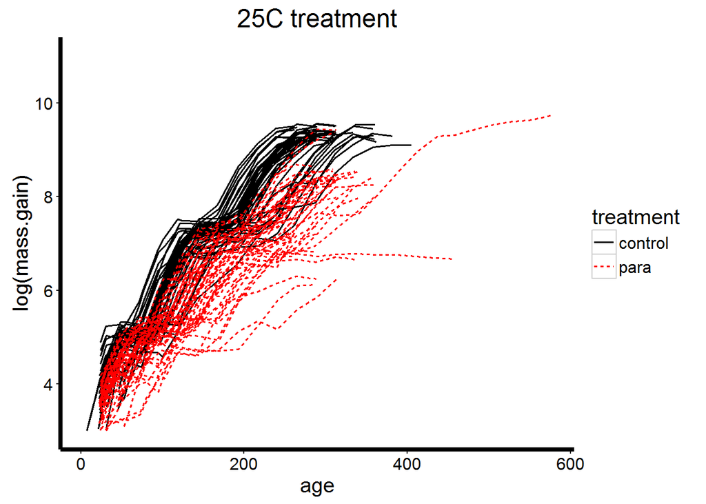

20C

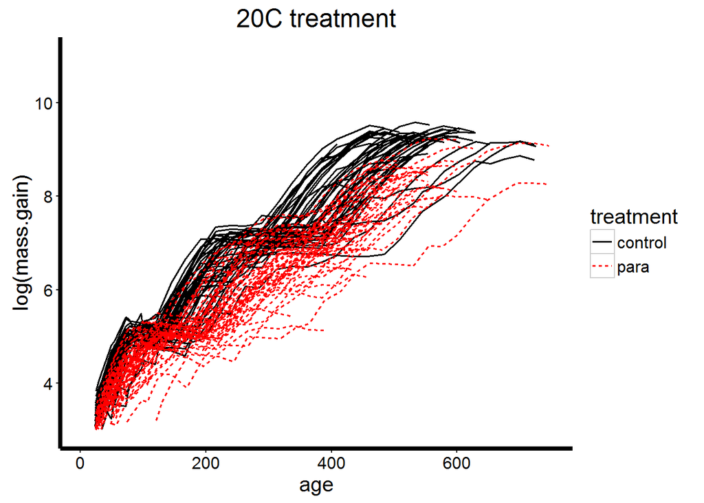

### Plotting consumption and age

Plot of actual age and consumption, all temps and individuals

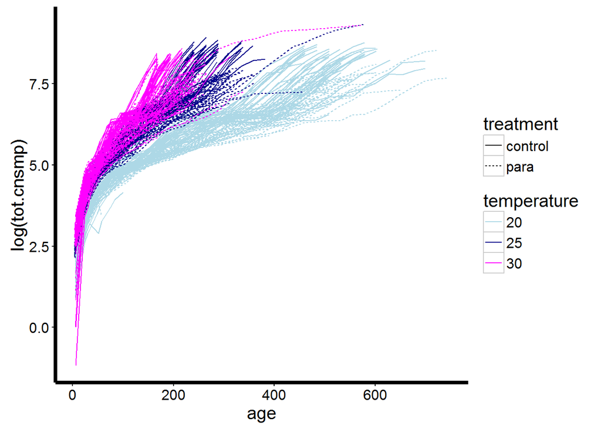

```r
k<- ggplot(cpt, aes(age, log(tot.cnsmp), group=interaction(bug.id, temp), color=factor(temp)))
k+geom_line(aes(linetype=treatment)
)+theme_bw(
)+theme(plot.background = element_blank(),panel.grid.major = element_blank(),
        panel.grid.minor = element_blank(), panel.border= element_blank(),
        axis.line.x = element_line(color="black", size = 1.5),
        axis.line.y = element_line(color="black", size = 1.5),text = element_text(size = 15)
)+scale_color_manual(values=c( "lightblue","darkblue", "magenta"),
                     guide=guide_legend(title="temperature"))
```

There are some negative values in here–need to decide what we should do with those–leave as negative, or make 0s or NAs

Tot.cnsmp not logged:

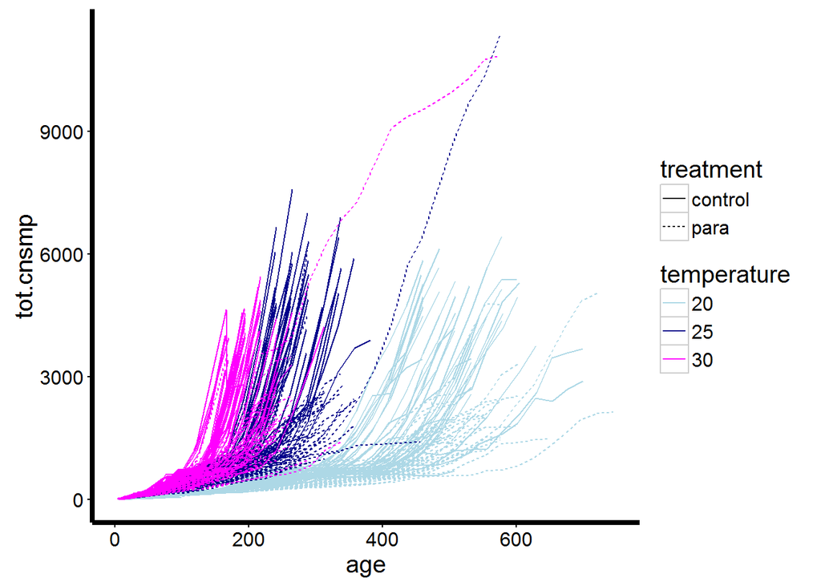

```r
k<- ggplot(cpt, aes(age, tot.cnsmp, group=interaction(bug.id, temp), color=factor(temp)))
k+geom_line(aes(linetype=treatment)
)+theme_bw(
)+theme(plot.background = element_blank(),panel.grid.major = element_blank(),
        panel.grid.minor = element_blank(), panel.border= element_blank(),
        axis.line.x = element_line(color="black", size = 1.5),
        axis.line.y = element_line(color="black", size = 1.5),text = element_text(size = 15)
)+scale_color_manual(values=c( "lightblue","darkblue", "magenta"),
                     guide=guide_legend(title="temperature"))
```

Plot of actual age and consumption, all individuals, faceted by temp

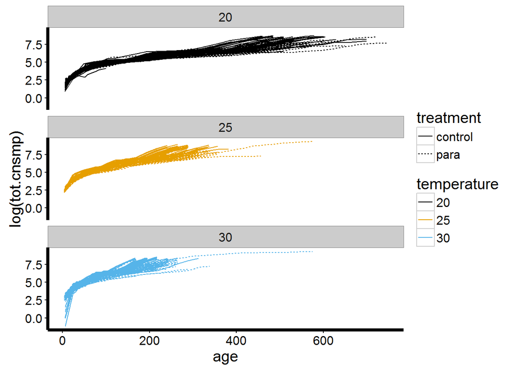

Plotting age and consumption for each temperature separately:

30C

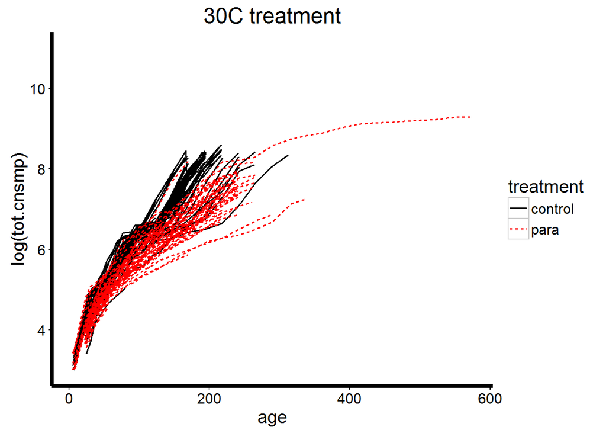

25C

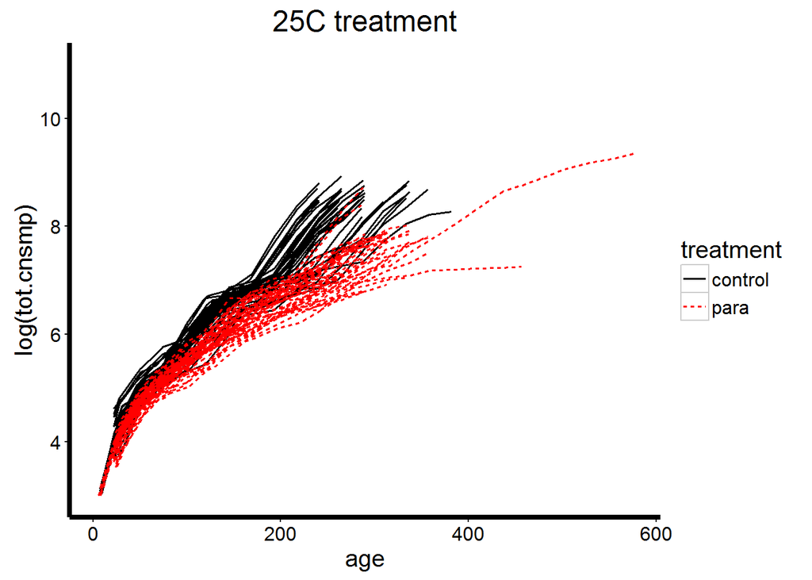

20C

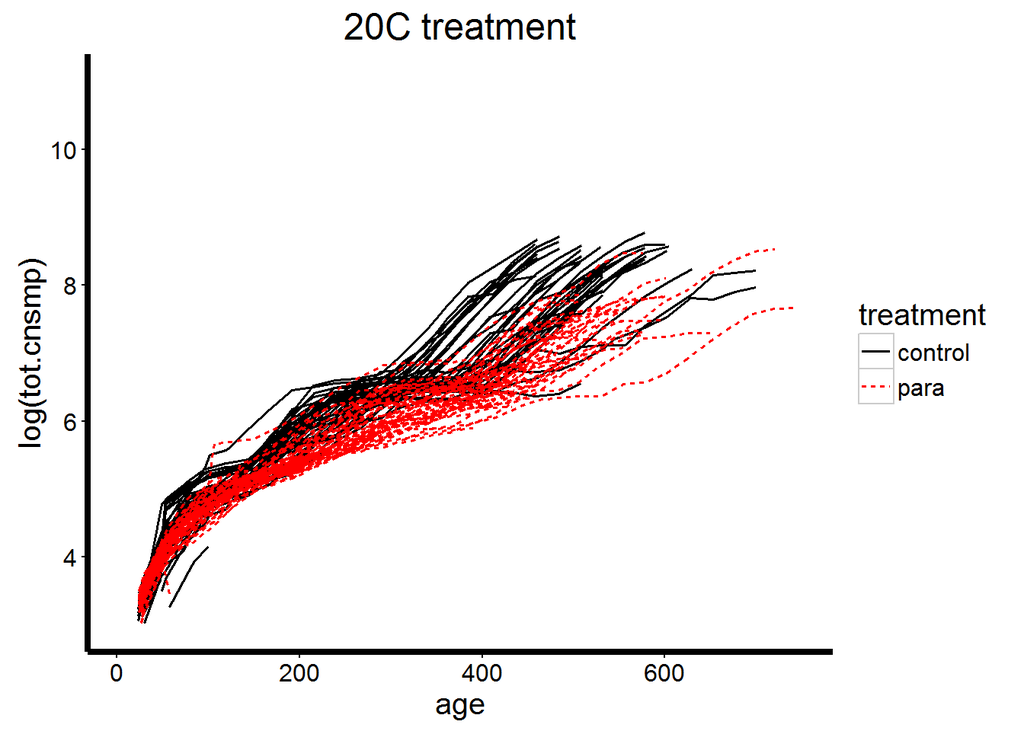

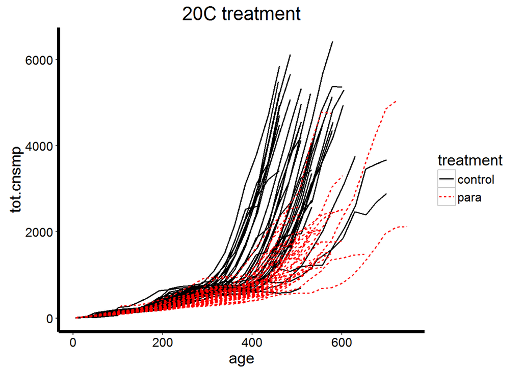

Plotting log(mass) by log(total consumption)

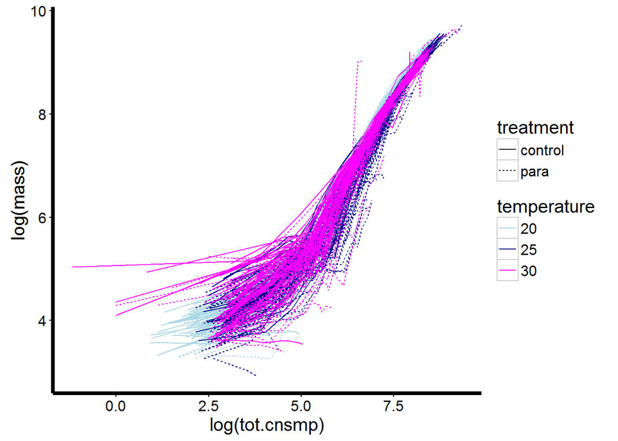

```r
k<- ggplot(cpt, aes(log(tot.cnsmp),log(mass), group=interaction(bug.id, temp), color=factor(temp)))
k+geom_line(aes(linetype=treatment)
)+theme_bw(
)+theme(plot.background = element_blank(),panel.grid.major = element_blank(),
        panel.grid.minor = element_blank(), panel.border= element_blank(),
        axis.line.x = element_line(color="black", size = 1.5),
        axis.line.y = element_line(color="black", size = 1.5),text = element_text(size = 15)
)+scale_color_manual(values=c( "lightblue","darkblue", "magenta"),
                     guide=guide_legend(title="temperature"))
```

Plotting mass by total consumption separately for each temperature:

30C-no logging of data

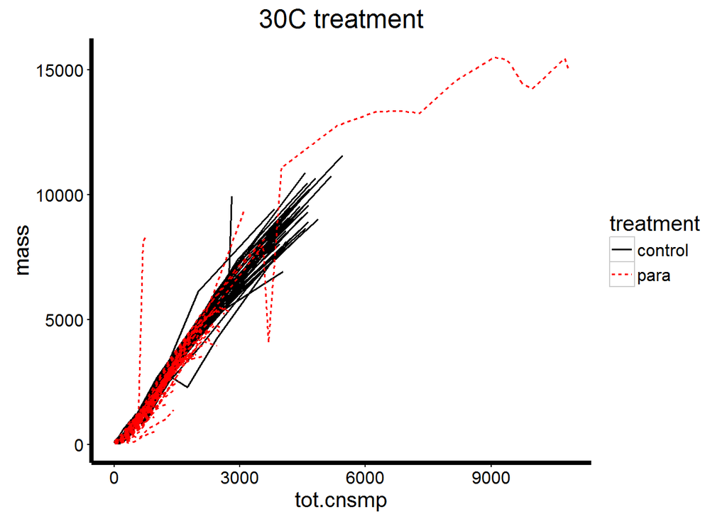

```r
k<- ggplot(cpt.30,aes(tot.cnsmp,mass,group=interaction(bug.id, temp), color=treatment))
k+geom_line(aes(linetype=treatment),size=.7
            )+theme_bw(
            )+theme(plot.background = element_blank(),panel.grid.major = element_blank(),
                    panel.grid.minor = element_blank(), panel.border= element_blank(),
                    axis.line.x = element_line(color="black", size = 1.5),
                    axis.line.y = element_line(color="black", size = 1.5),text = element_text(size = 15)
            )+scale_color_manual(values=c("black","red"),
                     guide=guide_legend(title="treatment")
            )+labs(title="30C treatment")
```

30C–log(tot.cnsmp) and log(mass)

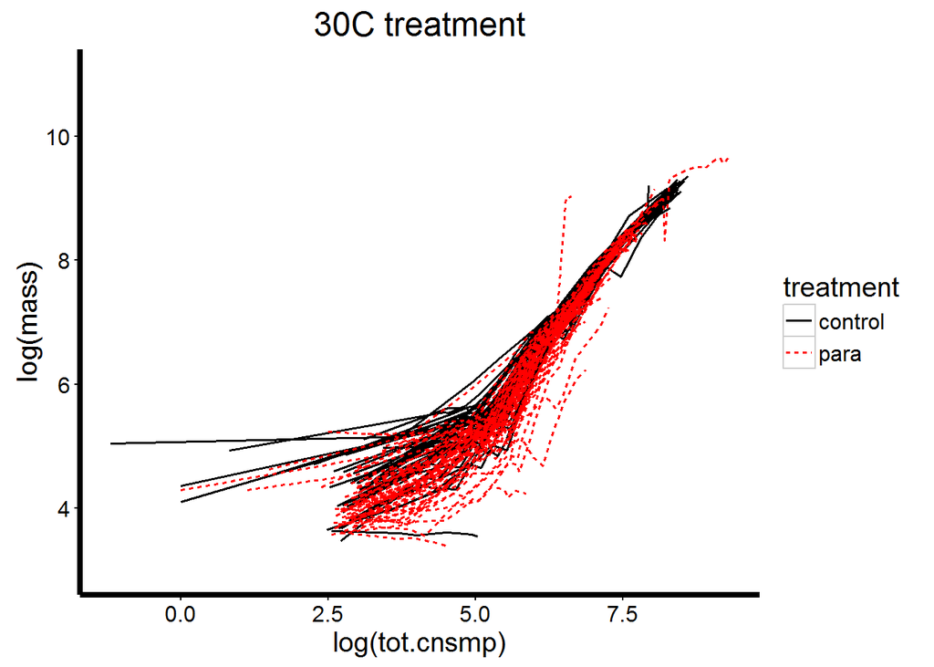

```r
k<- ggplot(cpt.30,aes(log(tot.cnsmp),log(mass),group=interaction(bug.id, temp), color=treatment))
k+geom_line(aes(linetype=treatment),size=.7
            )+theme_bw(
            )+theme(plot.background = element_blank(),panel.grid.major = element_blank(),
                    panel.grid.minor = element_blank(), panel.border= element_blank(),
                    axis.line.x = element_line(color="black", size = 1.5),
                    axis.line.y = element_line(color="black", size = 1.5),text = element_text(size = 15)
            )+scale_color_manual(values=c("black","red"),
                     guide=guide_legend(title="treatment")
            )+scale_y_continuous(limits=c(3,11),breaks = c(4,6,8,10)
            )+labs(title="30C treatment")
```

25C–no logging of data

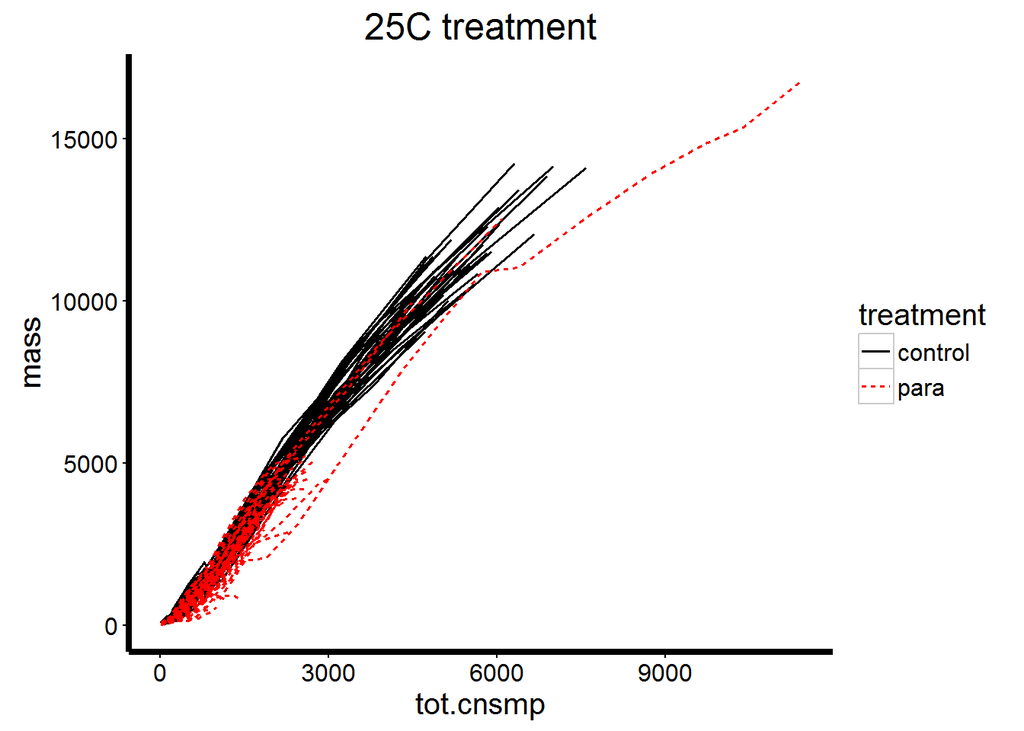

```r
k<- ggplot(cpt.25,aes(tot.cnsmp, mass,group=interaction(bug.id, temp), color=treatment))
k+geom_line(aes(linetype=treatment),size=.7
            )+theme_bw(
            )+theme(plot.background = element_blank(),panel.grid.major = element_blank(),
                    panel.grid.minor = element_blank(), panel.border= element_blank(),
                    axis.line.x = element_line(color="black", size = 1.5),
                    axis.line.y = element_line(color="black", size = 1.5),text = element_text(size = 15)
            )+scale_color_manual(values=c("black","red"),
                     guide=guide_legend(title="treatment")
            )+labs(title="25C treatment")
```

25C–log(tot.cnsmp) and log(mass)

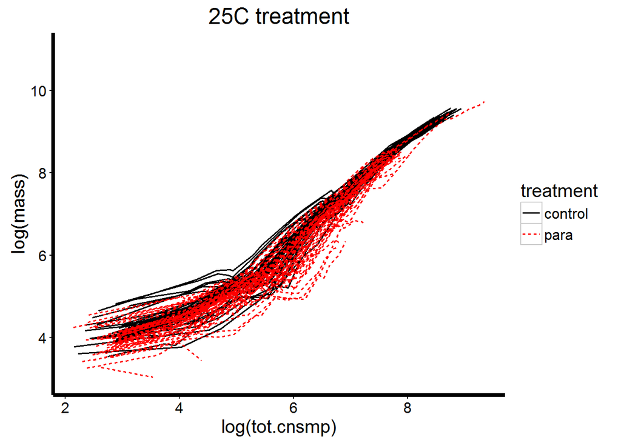

```r
k<- ggplot(cpt.25,aes(log(tot.cnsmp),log(mass),group=interaction(bug.id, temp), color=treatment))
k+geom_line(aes(linetype=treatment),size=.7
            )+theme_bw(
            )+theme(plot.background = element_blank(),panel.grid.major = element_blank(),
                    panel.grid.minor = element_blank(), panel.border= element_blank(),
                    axis.line.x = element_line(color="black", size = 1.5),
                    axis.line.y = element_line(color="black", size = 1.5),text = element_text(size = 15)
            )+scale_color_manual(values=c("black","red"),
                     guide=guide_legend(title="treatment")
            )+scale_y_continuous(limits=c(3,11),breaks = c(4,6,8,10)
            )+labs(title="25C treatment")
```

20C–no logging of data

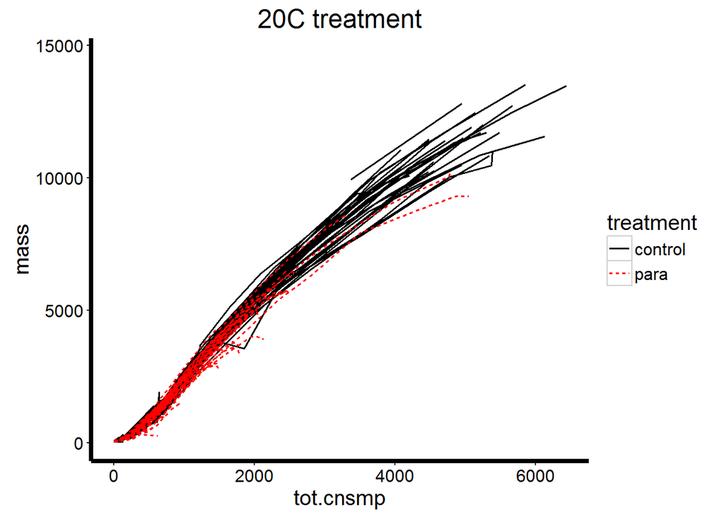

```r
k<- ggplot(cpt.20,aes(tot.cnsmp, mass,group=interaction(bug.id, temp), color=treatment))
k+geom_line(aes(linetype=treatment),size=.7
            )+theme_bw(
            )+theme(plot.background = element_blank(),panel.grid.major = element_blank(),
                    panel.grid.minor = element_blank(), panel.border= element_blank(),
                    axis.line.x = element_line(color="black", size = 1.5),
                    axis.line.y = element_line(color="black", size = 1.5),text = element_text(size = 15)
            )+scale_color_manual(values=c("black","red"),
                     guide=guide_legend(title="treatment")
            )+labs(title="20C treatment")
```

20C–log(tot.cnsmp) and log(mass)

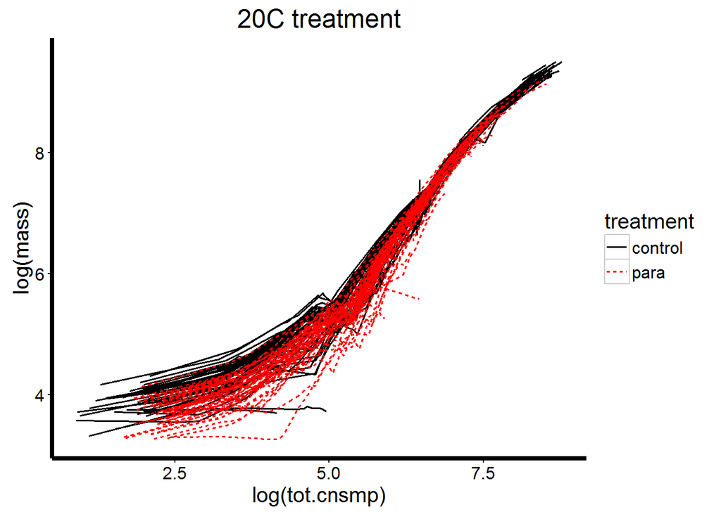

```r
k<- ggplot(cpt.20,aes(log(tot.cnsmp), log(mass),group=interaction(bug.id, temp), color=treatment))
k+geom_line(aes(linetype=treatment),size=.7
            )+theme_bw(
            )+theme(plot.background = element_blank(),panel.grid.major = element_blank(),
                    panel.grid.minor = element_blank(), panel.border= element_blank(),
                    axis.line.x = element_line(color="black", size = 1.5),
                    axis.line.y = element_line(color="black", size = 1.5),text = element_text(size = 15)
            )+scale_color_manual(values=c("black","red"),
                     guide=guide_legend(title="treatment")
            )+labs(title="20C treatment")
```

### SummarySEs of variables

Age at 4th instar:

```r
age4.sum <- summarySE(wide, measurevar="age.4",
                    groupvars=c("temp", "treatment"),na.rm=TRUE)

age4.sum
```

```
##   temp treatment  N     age.4       sd       se       ci
## 1   20   control 41 141.20081 22.33999 3.488920 7.051371
## 2   20      para 53 188.36415 30.10549 4.135307 8.298102
## 3   25   control 38  79.04035 12.23959 1.985524 4.023055
## 4   25      para 51 116.76471 26.95950 3.775086 7.582483
## 5   30   control 40  51.86708 11.92921 1.886173 3.815145
## 6   30      para 54  79.16790 22.81289 3.104441 6.226720
```

Age at 5th instar

```r
age5.sum <- summarySE(wide, measurevar="age.5",
                      groupvars=c("temp", "treatment"),na.rm=TRUE)

age5.sum
```

```
##   temp treatment  N    age.5       sd       se        ci
## 1   20   control 41 349.5171 44.72641 6.985092 14.117397
## 2   20      para 33 390.1621 44.50204 7.746811 15.779739
## 3   25   control 39 195.5000 24.67846 3.951716  7.999830
## 4   25      para 34 226.6392 25.01207 4.289534  8.727123
## 5   30   control 39 133.2077 24.17738 3.871478  7.837398
## 6   30      para 41 157.8228 24.29232 3.793823  7.667602
```

Age at wandering

```r
agewand.sum<- summarySE(wide, measurevar="age.wander",
                        groupvars=c("temp"),na.rm=TRUE)

agewand.sum
```

```
##   temp  N age.wander       sd        se        ci
## 1   20 44   564.8136 72.82559 10.978871 22.141003
## 2   25 41   307.0614 34.17845  5.337777 10.788050
## 3   30 41   227.5927 30.04520  4.692271  9.483434
```

Age at emergence

```r
ageem.sum<- summarySE(wide, measurevar="age.em",
                      groupvars=c("temp"),na.rm=TRUE)

ageem.sum
```

```
##   temp  N   age.em       sd       se        ci
## 1   20 48 530.9295 68.83166 9.934995 19.986632
## 2   25 46 323.1815 29.33574 4.325319  8.711639
## 3   30 46 262.5587 23.14361 3.412339  6.872803
```

Mass at 3rd instar:

```r
mass3.sum<-summarySE(wide, measurevar="mass.T0",
                     groupvars=c("temp", "treatment"),na.rm=TRUE)
mass3.sum
```

```
##   temp treatment  N  mass.T0        sd       se       ci
## 1   20   control 43 47.57605  9.221674 1.406292 2.838012
## 2   20      para 53 37.87528  7.730871 1.061917 2.130892
## 3   25   control 39 55.76077 18.589486 2.976700 6.026014
## 4   25      para 53 49.15019 15.214127 2.089821 4.193533
## 5   30   control 41 62.46902 27.105922 4.233234 8.555685
## 6   30      para 56 55.04554 24.489556 3.272555 6.558346
```

Mass at 4th intar:

```r
mass4.sum<-summarySE(wide, measurevar="mass.4",
                     groupvars=c("temp", "treatment"),na.rm=TRUE)
mass4.sum
```

```
##   temp treatment  N   mass.4       sd       se       ci
## 1   20   control 41 210.2880 33.00599 5.154669 10.41798
## 2   20      para 53 194.1666 45.28488 6.220357 12.48206
## 3   25   control 38 215.8700 55.36494 8.981380 18.19800
## 4   25      para 51 220.5855 59.26109 8.298213 16.66745
## 5   30   control 40 197.9155 53.38316 8.440618 17.07276
## 6   30      para 54 182.1856 50.28632 6.843102 13.72552
```

Mass at 5th instar:

```r
mass5.sum<-summarySE(wide, measurevar="mass.5",
                     groupvars=c("temp", "treatment"),na.rm=TRUE)
mass5.sum
```

```
##   temp treatment  N   mass.5       sd        se        ci
## 1   20   control 41 1329.715 220.2164  34.39202  69.50886
## 2   20      para 33 1213.473 422.9176  73.62051 149.96007
## 3   25   control 39 1861.219 373.1685  59.75478 120.96724
## 4   25      para 34 1449.370 459.8907  78.87060 160.46344
## 5   30   control 39 1369.542 742.9831 118.97252 240.84727
## 6   30      para 41 1259.653 449.4997  70.20005 141.87960
```

Mass at wandering:

```r
masswand.sum<-summarySE(wide, measurevar="mass.wander",
                                 groupvars=c("temp"),na.rm=TRUE)
masswand.sum
```

```
##   temp  N mass.wander       sd       se       ci
## 1   20 44    10371.99 1472.604 222.0034 447.7125
## 2   25 41    11525.68 1260.194 196.8093 397.7663
## 3   30 41     8870.53 1181.081 184.4539 372.7953
```

Mass at time point before emergence

```r
massem.sum<-summarySE(wide, measurevar="mass.befem",
                      groupvars=c("temp"),na.rm=TRUE)

massem.sum
```

```
##   temp  N mass.befem       sd       se       ci
## 1   20 48   3079.293 1738.768 250.9695 504.8855
## 2   25 46   3239.798 1567.906 231.1751 465.6105
## 3   30 50   3563.364 1777.232 251.3386 505.0838
```

Number of wasp larvae emerged:

```r
numem.sum<-summarySE(wide, measurevar="num.em",
                     groupvars=c("temp"),na.rm=TRUE)

numem.sum
```

```
##   temp  N   num.em       sd       se        ci
## 1   20 96 51.18750 66.88739 6.826665 13.552644
## 2   25 92 54.86957 71.27754 7.431198 14.761161
## 3   30 97 27.00000 33.64583 3.416216  6.781135
```

### Plots of averages

Average age at 4th instar–by temperature and treatment

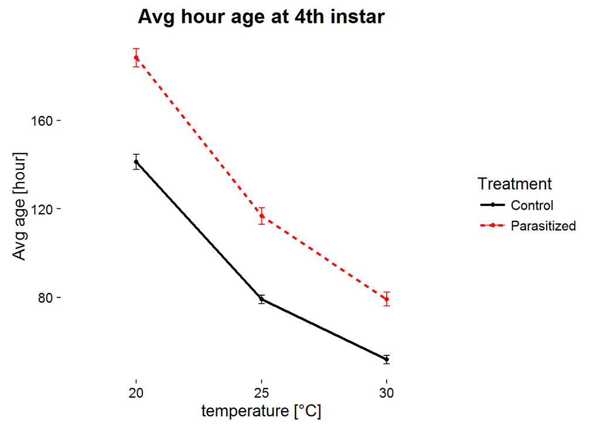

Preliminary linear model of age at 4th instar (temp*treatment)

```r
#lm mods for age at 4th and 5th instar


age4.mod<-lm(age.4~temp*treatment,data=wide)
anova(age4.mod)
```

```
## Analysis of Variance Table
##
## Response: age.4
##                 Df Sum Sq Mean Sq F value  Pr(>F)
## temp             2 489767  244883 466.990 < 2e-16 ***
## treatment        1  94987   94987 181.140 < 2e-16 ***
## temp:treatment   2   4550    2275   4.338 0.01398 *
## Residuals      271 142109     524
## ---
## Signif. codes:  0 '***' 0.001 '**' 0.01 '*' 0.05 '.' 0.1 ' ' 1
```

```r
summary(age4.mod)
```

```
##
## Call:
## lm(formula = age.4 ~ temp * treatment, data = wide)
##
## Residuals:
##     Min      1Q  Median      3Q     Max
## -68.247 -14.048  -2.067   7.885  89.365
##
## Coefficients:
##                      Estimate Std. Error t value Pr(>|t|)
## (Intercept)           141.201      3.576  39.482  < 2e-16 ***
## temp25                -62.160      5.157 -12.055  < 2e-16 ***
## temp30                -89.334      5.089 -17.554  < 2e-16 ***
## treatmentpara          47.163      4.763   9.902  < 2e-16 ***
## temp25:treatmentpara   -9.439      6.839  -1.380  0.16864
## temp30:treatmentpara  -19.863      6.746  -2.944  0.00352 **
## ---
## Signif. codes:  0 '***' 0.001 '**' 0.01 '*' 0.05 '.' 0.1 ' ' 1
##
## Residual standard error: 22.9 on 271 degrees of freedom
##   (8 observations deleted due to missingness)
## Multiple R-squared:  0.8057, Adjusted R-squared:  0.8021
## F-statistic: 224.8 on 5 and 271 DF,  p-value: < 2.2e-16
```

Average age at 5th instar–by temperature and treatment

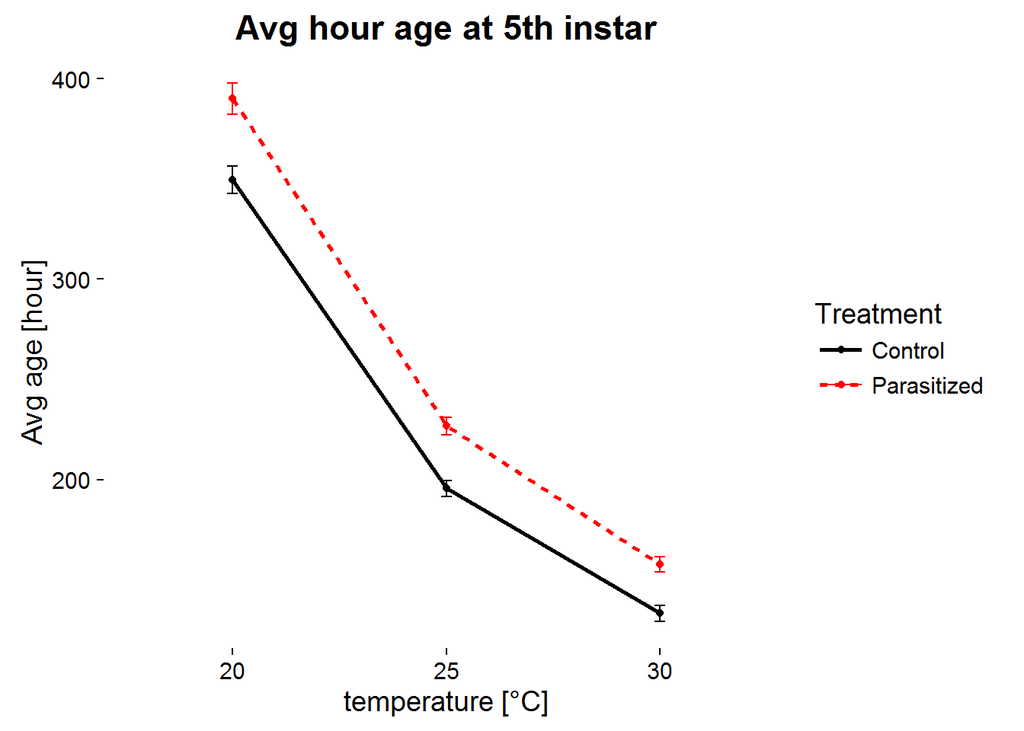

Preliminary linear model of age at 5th instar (temp*treatment)

```r
age5.mod<-lm(age.5~temp*treatment,data=wide)
anova(age5.mod)
```

```
## Analysis of Variance Table
##
## Response: age.5
##                 Df  Sum Sq Mean Sq  F value    Pr(>F)
## temp             2 1980545  990272 939.2825 < 2.2e-16 ***
## treatment        1   57459   57459  54.5006 3.129e-12 ***
## temp:treatment   2    2470    1235   1.1712    0.3119
## Residuals      221  232997    1054
## ---
## Signif. codes:  0 '***' 0.001 '**' 0.01 '*' 0.05 '.' 0.1 ' ' 1
```

```r
summary(age5.mod)
```

```
##
## Call:
## lm(formula = age.5 ~ temp * treatment, data = wide)
##
## Residuals:
##     Min      1Q  Median      3Q     Max
## -76.012 -26.192  -4.174  14.186 140.338
##
## Coefficients:
##                      Estimate Std. Error t value Pr(>|t|)
## (Intercept)           349.517      5.071  68.926  < 2e-16 ***
## temp25               -154.017      7.263 -21.206  < 2e-16 ***
## temp30               -216.309      7.263 -29.783  < 2e-16 ***
## treatmentpara          40.645      7.594   5.353 2.17e-07 ***
## temp25:treatmentpara   -9.506     10.757  -0.884    0.378
## temp30:treatmentpara  -16.030     10.508  -1.526    0.129
## ---
## Signif. codes:  0 '***' 0.001 '**' 0.01 '*' 0.05 '.' 0.1 ' ' 1
##
## Residual standard error: 32.47 on 221 degrees of freedom
##   (58 observations deleted due to missingness)
## Multiple R-squared:  0.8975, Adjusted R-squared:  0.8952
## F-statistic: 387.1 on 5 and 221 DF,  p-value: < 2.2e-16
```

Interaction term not significant, removing from model:

```r
age5.mod2<-lm(age.5~temp+treatment,data=wide)
anova(age5.mod2)
```

```
## Analysis of Variance Table
##
## Response: age.5
##            Df  Sum Sq Mean Sq F value    Pr(>F)
## temp        2 1980545  990272 937.843 < 2.2e-16 ***
## treatment   1   57459   57459  54.417 3.163e-12 ***
## Residuals 223  235467    1056
## ---
## Signif. codes:  0 '***' 0.001 '**' 0.01 '*' 0.05 '.' 0.1 ' ' 1
```

Testing the full and reduced model

```r
anova(age5.mod,age5.mod2)
```

```
## Analysis of Variance Table
##
## Model 1: age.5 ~ temp * treatment
## Model 2: age.5 ~ temp + treatment
##   Res.Df    RSS Df Sum of Sq      F Pr(>F)
## 1    221 232997
## 2    223 235467 -2   -2469.5 1.1712 0.3119
```

Not significantly differet, so can use the reduced model

Average mass at 4th instar–by temperature and treatment

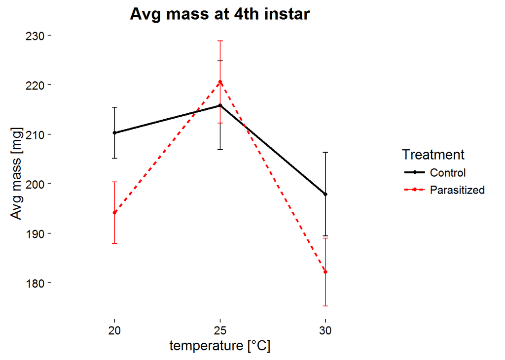

Preliminary linear model of mass at 4th instar (tempXtreatmentXage)

```r
mass4.mod<-lm(mass.4~treatment*temp*age.4,data=wide)
anova(mass4.mod)
```

```
## Analysis of Variance Table
##
## Response: mass.4
##                       Df Sum Sq Mean Sq F value    Pr(>F)
## treatment              1   5886  5886.2  2.3270 0.1283403
## temp                   2  40575 20287.3  8.0202 0.0004152 ***
## age.4                  1    107   106.5  0.0421 0.8375740
## treatment:temp         2   6304  3151.8  1.2460 0.2893270
## treatment:age.4        1     89    89.3  0.0353 0.8511118
## temp:age.4             2  11859  5929.6  2.3441 0.0979163 .
## treatment:temp:age.4   2   2005  1002.3  0.3962 0.6732415
## Residuals            265 670325  2529.5
## ---
## Signif. codes:  0 '***' 0.001 '**' 0.01 '*' 0.05 '.' 0.1 ' ' 1
```

```r
summary(mass4.mod)
```

```
##
## Call:
## lm(formula = mass.4 ~ treatment * temp * age.4, data = wide)
##
## Residuals:
##      Min       1Q   Median       3Q      Max
## -116.039  -31.187   -6.309   22.662  189.080
##
## Coefficients:
##                             Estimate Std. Error t value Pr(>|t|)
## (Intercept)                195.22101   50.87252   3.837 0.000155 ***
## treatmentpara                0.43886   67.38001   0.007 0.994808
## temp25                      18.41478   74.19978   0.248 0.804189
## temp30                       2.34239   62.26860   0.038 0.970021
## age.4                        0.10671    0.35596   0.300 0.764590
## treatmentpara:temp25       -44.25723   91.95794  -0.481 0.630717
## treatmentpara:temp30        23.93780   80.31845   0.298 0.765909
## treatmentpara:age.4         -0.11463    0.42471  -0.270 0.787441
## temp25:age.4                -0.07844    0.76359  -0.103 0.918259
## temp30:age.4                -0.09992    0.76321  -0.131 0.895939
## treatmentpara:temp25:age.4   0.52116    0.84044   0.620 0.535726
## treatmentpara:temp30:age.4  -0.39431    0.85315  -0.462 0.644332
## ---
## Signif. codes:  0 '***' 0.001 '**' 0.01 '*' 0.05 '.' 0.1 ' ' 1
##
## Residual standard error: 50.29 on 265 degrees of freedom
##   (8 observations deleted due to missingness)
## Multiple R-squared:  0.09065,    Adjusted R-squared:  0.05291
## F-statistic: 2.402 on 11 and 265 DF,  p-value: 0.007428
```

Removing nonsignificant predictors (-trt:age.4):

```r
mass4.mod2<-lm(mass.4~treatment+temp+age.4+treatment:temp+temp:age.4+treatment:temp:age.4,data=wide)
anova(mass4.mod2)
```

```
## Analysis of Variance Table
##
## Response: mass.4
##                       Df Sum Sq Mean Sq F value    Pr(>F)
## treatment              1   5886  5886.2  2.3270 0.1283403
## temp                   2  40575 20287.3  8.0202 0.0004152 ***
## age.4                  1    107   106.5  0.0421 0.8375740
## treatment:temp         2   6304  3151.8  1.2460 0.2893270
## temp:age.4             2  11777  5888.6  2.3279 0.0994869 .
## treatment:temp:age.4   3   2176   725.3  0.2867 0.8349728
## Residuals            265 670325  2529.5
## ---
## Signif. codes:  0 '***' 0.001 '**' 0.01 '*' 0.05 '.' 0.1 ' ' 1
```

Removing 3 way interaction (temp:trt:age.4)

```r
mass4.mod3<-lm(mass.4~treatment+temp+age.4+treatment:temp+temp:age.4,data=wide)
anova(mass4.mod3)
```

```
## Analysis of Variance Table
##
## Response: mass.4
##                 Df Sum Sq Mean Sq F value    Pr(>F)
## treatment        1   5886  5886.2  2.3457 0.1268073
## temp             2  40575 20287.3  8.0848 0.0003897 ***
## age.4            1    107   106.5  0.0424 0.8369291
## treatment:temp   2   6304  3151.8  1.2560 0.2864479
## temp:age.4       2  11777  5888.6  2.3467 0.0976497 .
## Residuals      268 672501  2509.3
## ---
## Signif. codes:  0 '***' 0.001 '**' 0.01 '*' 0.05 '.' 0.1 ' ' 1
```

Removing age.4

```r
mass4.mod4<-lm(mass.4~treatment+temp+treatment:temp+temp:age.4,data=wide)
anova(mass4.mod4)
```

```
## Analysis of Variance Table
##
## Response: mass.4
##                 Df Sum Sq Mean Sq F value    Pr(>F)
## treatment        1   5886  5886.2  2.3457 0.1268073
## temp             2  40575 20287.3  8.0848 0.0003897 ***
## treatment:temp   2   6303  3151.6  1.2559 0.2864796
## temp:age.4       3  11884  3961.4  1.5787 0.1948492
## Residuals      268 672501  2509.3
## ---
## Signif. codes:  0 '***' 0.001 '**' 0.01 '*' 0.05 '.' 0.1 ' ' 1
```

Removing treatment:temp interaction:

```r
mass4.mod5<-lm(mass.4~treatment+temp+temp:age.4,data=wide)
anova(mass4.mod5)
```

```
## Analysis of Variance Table
##
## Response: mass.4
##             Df Sum Sq Mean Sq F value    Pr(>F)
## treatment    1   5886  5886.2  2.3590 0.1257299
## temp         2  40575 20287.3  8.1307 0.0003725 ***
## temp:age.4   3  16995  5664.9  2.2704 0.0806974 .
## Residuals  270 673693  2495.2
## ---
## Signif. codes:  0 '***' 0.001 '**' 0.01 '*' 0.05 '.' 0.1 ' ' 1
```

Removing treatment:

```r
mass4.mod6<-lm(mass.4~temp+temp:age.4,data=wide)
anova(mass4.mod6)
```

```
## Analysis of Variance Table
##
## Response: mass.4
##             Df Sum Sq Mean Sq F value    Pr(>F)
## temp         2  40586 20293.0  8.1125 0.0003787 ***
## temp:age.4   3  18666  6222.1  2.4874 0.0608637 .
## Residuals  271 677897  2501.5
## ---
## Signif. codes:  0 '***' 0.001 '**' 0.01 '*' 0.05 '.' 0.1 ' ' 1
```

```r
summary(mass4.mod6)
```

```
##
## Call:
## lm(formula = mass.4 ~ temp + temp:age.4, data = wide)
##
## Residuals:
##      Min       1Q   Median       3Q      Max
## -122.746  -31.186   -7.471   23.914  194.241
##
## Coefficients:
##              Estimate Std. Error t value Pr(>|t|)
## (Intercept)  223.5968    24.9172   8.974   <2e-16 ***
## temp25       -32.4166    31.5716  -1.027   0.3054
## temp30        -2.8894    29.5734  -0.098   0.9222
## temp20:age.4  -0.1335     0.1453  -0.919   0.3590
## temp25:age.4   0.2721     0.1853   1.469   0.1430
## temp30:age.4  -0.4712     0.2231  -2.112   0.0356 *
## ---
## Signif. codes:  0 '***' 0.001 '**' 0.01 '*' 0.05 '.' 0.1 ' ' 1
##
## Residual standard error: 50.01 on 271 degrees of freedom
##   (8 observations deleted due to missingness)
## Multiple R-squared:  0.08038,    Adjusted R-squared:  0.06341
## F-statistic: 4.737 on 5 and 271 DF,  p-value: 0.0003633
```

Testing models:

```r
anova(mass4.mod,mass4.mod6)
```

```
## Analysis of Variance Table
##
## Model 1: mass.4 ~ treatment * temp * age.4
## Model 2: mass.4 ~ temp + temp:age.4
##   Res.Df    RSS Df Sum of Sq      F Pr(>F)
## 1    265 670325
## 2    271 677897 -6   -7571.7 0.4989  0.809
```

Not significantly different, can use reduced model

Average mass at 5th instar–by temperature and treatment

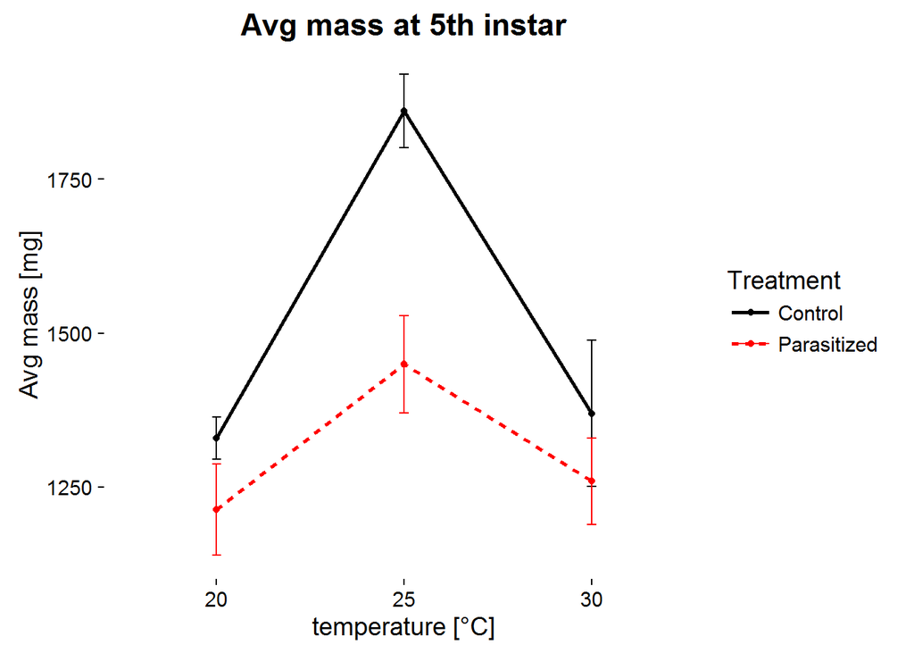

```r
mass5.mod<-lm(mass.5~temp*treatment*age.5,data=wide)
anova(mass5.mod)
```

```
## Analysis of Variance Table
##
## Response: mass.5
##                       Df   Sum Sq Mean Sq F value    Pr(>F)
## temp                   2  6944188 3472094 16.4080 2.335e-07 ***
## treatment              1  2468370 2468370 11.6647 0.0007614 ***
## age.5                  1   197730  197730  0.9344 0.3348060
## temp:treatment         2  1097279  548640  2.5927 0.0771560 .
## temp:age.5             2  2670444 1335222  6.3098 0.0021731 **
## treatment:age.5        1    34411   34411  0.1626 0.6871622
## temp:treatment:age.5   2   598522  299261  1.4142 0.2453691
## Residuals            215 45496064  211610
## ---
## Signif. codes:  0 '***' 0.001 '**' 0.01 '*' 0.05 '.' 0.1 ' ' 1
```

Removing treatment and age interaction (trt:age.5)

```r
mass5.mod2<-lm(mass.5~temp+treatment+age.5+temp:treatment+temp:age.5+temp:treatment:age.5,data=wide)
anova(mass5.mod2)
```

```
## Analysis of Variance Table
##
## Response: mass.5
##                       Df   Sum Sq Mean Sq F value    Pr(>F)
## temp                   2  6944188 3472094 16.4080 2.335e-07 ***
## treatment              1  2468370 2468370 11.6647 0.0007614 ***
## age.5                  1   197730  197730  0.9344 0.3348060
## temp:treatment         2  1097279  548640  2.5927 0.0771560 .
## temp:age.5             2  2670444 1335222  6.3098 0.0021731 **
## temp:treatment:age.5   3   632933  210978  0.9970 0.3951365
## Residuals            215 45496064  211610
## ---
## Signif. codes:  0 '***' 0.001 '**' 0.01 '*' 0.05 '.' 0.1 ' ' 1
```

Removing 3 way interaction (temp:treatment:age.5)

```r
mass5.mod3<-lm(mass.5~temp+treatment+age.5+temp:treatment+temp:age.5,data=wide)
anova(mass5.mod3)
```

```
## Analysis of Variance Table
##
## Response: mass.5
##                 Df   Sum Sq Mean Sq F value    Pr(>F)
## temp             2  6944188 3472094 16.4087   2.3e-07 ***
## treatment        1  2468370 2468370 11.6652 0.0007594 ***
## age.5            1   197730  197730  0.9344 0.3347812
## temp:treatment   2  1097279  548640  2.5928 0.0771158 .
## temp:age.5       2  2670444 1335222  6.3101 0.0021674 **
## Residuals      218 46128997  211601
## ---
## Signif. codes:  0 '***' 0.001 '**' 0.01 '*' 0.05 '.' 0.1 ' ' 1
```

Removing age.5

```r
mass5.mod4<-lm(mass.5~temp+treatment+temp:treatment+temp:age.5,data=wide)
anova(mass5.mod4)
```

```
## Analysis of Variance Table
##
## Response: mass.5
##                 Df   Sum Sq Mean Sq F value    Pr(>F)
## temp             2  6944188 3472094 16.4087   2.3e-07 ***
## treatment        1  2468370 2468370 11.6652 0.0007594 ***
## temp:treatment   2  1101073  550536  2.6018 0.0764436 .
## temp:age.5       3  2864380  954793  4.5122 0.0042971 **
## Residuals      218 46128997  211601
## ---
## Signif. codes:  0 '***' 0.001 '**' 0.01 '*' 0.05 '.' 0.1 ' ' 1
```

Removing temp:treatment

```r
mass5.mod5<-lm(mass.5~temp+treatment+temp:age.5,data=wide)
anova(mass5.mod5)
```

```
## Analysis of Variance Table
##
## Response: mass.5
##             Df   Sum Sq Mean Sq F value    Pr(>F)
## temp         2  6944188 3472094 16.2186 2.689e-07 ***
## treatment    1  2468370 2468370 11.5301 0.0008124 ***
## temp:age.5   3  2996666  998889  4.6659 0.0035015 **
## Residuals  220 47097784  214081
## ---
## Signif. codes:  0 '***' 0.001 '**' 0.01 '*' 0.05 '.' 0.1 ' ' 1
```

```r
summary(mass5.mod5)
```

```
##
## Call:
## lm(formula = mass.5 ~ temp + treatment + temp:age.5, data = wide)
##
## Residuals:
##     Min      1Q  Median      3Q     Max
## -1416.8  -244.4   -32.7   185.1  3892.5
##
## Coefficients:
##                 Estimate Std. Error t value Pr(>|t|)
## (Intercept)    1523.5103   419.2646   3.634 0.000348 ***
## temp25          452.7881   571.6974   0.792 0.429210
## temp30        -1138.6052   501.6213  -2.270 0.024186 *
## treatmentpara  -259.0198    69.8600  -3.708 0.000265 ***
## temp20:age.5     -0.3539     1.1501  -0.308 0.758557
## temp25:age.5     -0.8869     1.9750  -0.449 0.653819
## temp30:age.5      7.2764     2.0119   3.617 0.000370 ***
## ---
## Signif. codes:  0 '***' 0.001 '**' 0.01 '*' 0.05 '.' 0.1 ' ' 1
##
## Residual standard error: 462.7 on 220 degrees of freedom
##   (58 observations deleted due to missingness)
## Multiple R-squared:  0.2085, Adjusted R-squared:  0.1869
## F-statistic: 9.661 on 6 and 220 DF,  p-value: 1.946e-09
```

Testing models:

```r
anova(mass5.mod,mass5.mod5)
```

```
## Analysis of Variance Table
##
## Model 1: mass.5 ~ temp * treatment * age.5
## Model 2: mass.5 ~ temp + treatment + temp:age.5
##   Res.Df      RSS Df Sum of Sq      F Pr(>F)
## 1    215 45496064
## 2    220 47097784 -5  -1601719 1.5138 0.1866
```

Models not significantly different, can use reduced model

Plotting avg mass at wandering for control caterpillars by temperature

```
## geom_path: Each group consists of only one observation. Do you need to
## adjust the group aesthetic?
```

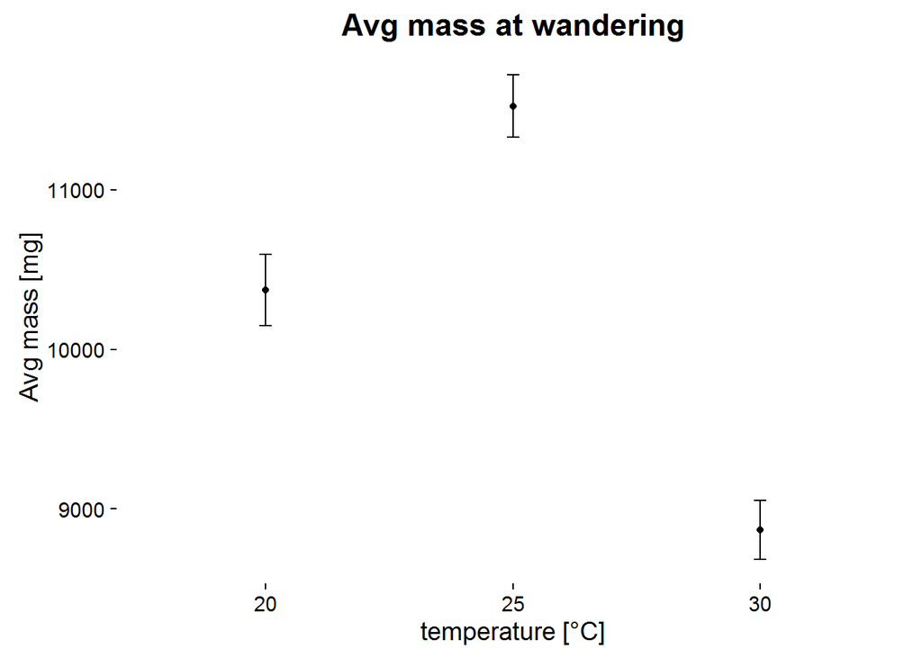

```r
masswand.plot <- ggplot(masswand.sum, aes(x=temp,y=mass.wander))
masswand.plot<-masswand.plot+geom_point()+geom_errorbar(aes(ymin=mass.wander-se,ymax=mass.wander+se),width=.05)+geom_line()+labs(title="Avg mass at wandering",x="temperature [°C]",
                   y="Avg mass [mg]"
               )+theme(axis.title.y=element_text(vjust=1.5),
                       axis.title.x=element_text(vjust=-.35),
                       plot.title=element_text(face="bold",vjust=1))



masswand.plot
```

Preliminary linear model of mass at wander by temperature and age at wander

```r
masswand.mod<-lm(mass.wander~temp*age.wander,data=wide)
anova(masswand.mod)
```

```
## Analysis of Variance Table
##
## Response: mass.wander
##                  Df    Sum Sq  Mean Sq F value    Pr(>F)
## temp              2 145387439 72693719 46.0941 1.405e-15 ***
## age.wander        1  21202517 21202517 13.4442 0.0003675 ***
## temp:age.wander   2   2118859  1059429  0.6718 0.5127139
## Residuals       120 189248525  1577071
## ---
## Signif. codes:  0 '***' 0.001 '**' 0.01 '*' 0.05 '.' 0.1 ' ' 1
```

Removing the interaction term (temp:age.wander)

```r
masswand.mod2<-lm(mass.wander~temp+age.wander,data=wide)
anova(masswand.mod2)
```

```
## Analysis of Variance Table
##
## Response: mass.wander
##             Df    Sum Sq  Mean Sq F value    Pr(>F)
## temp         2 145387439 72693719  46.343 1.066e-15 ***
## age.wander   1  21202517 21202517  13.517 0.0003527 ***
## Residuals  122 191367384  1568585
## ---
## Signif. codes:  0 '***' 0.001 '**' 0.01 '*' 0.05 '.' 0.1 ' ' 1
```

```r
summary(masswand.mod2)
```

```
##
## Call:
## lm(formula = mass.wander ~ temp + age.wander, data = wide)
##
## Residuals:
##     Min      1Q  Median      3Q     Max
## -3019.1  -731.4   -61.2   717.8  3273.0
##
## Coefficients:
##              Estimate Std. Error t value Pr(>|t|)
## (Intercept) 15036.399   1282.667  11.723  < 2e-16 ***
## temp25       -974.907    639.618  -1.524 0.130046
## temp30      -4286.337    804.780  -5.326 4.65e-07 ***
## age.wander     -8.258      2.246  -3.677 0.000353 ***
## ---
## Signif. codes:  0 '***' 0.001 '**' 0.01 '*' 0.05 '.' 0.1 ' ' 1
##
## Residual standard error: 1252 on 122 degrees of freedom
##   (159 observations deleted due to missingness)
## Multiple R-squared:  0.4654, Adjusted R-squared:  0.4522
## F-statistic:  35.4 on 3 and 122 DF,  p-value: < 2.2e-16
```

Testing models:

```r
anova(masswand.mod,masswand.mod2)
```

```
## Analysis of Variance Table
##
## Model 1: mass.wander ~ temp * age.wander
## Model 2: mass.wander ~ temp + age.wander
##   Res.Df       RSS Df Sum of Sq      F Pr(>F)
## 1    120 189248525
## 2    122 191367384 -2  -2118859 0.6718 0.5127
```

Models not significantly different, can use reduced model

Plotting average mass at wasp emergence for parasitized caterpillars by temperature

```
## geom_path: Each group consists of only one observation. Do you need to
## adjust the group aesthetic?
```

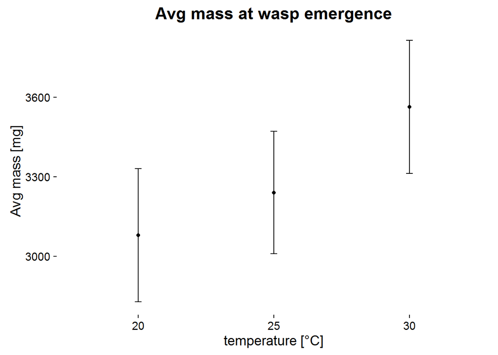

```r
massem.plot <- ggplot(massem.sum, aes(x=temp,y=mass.befem))
massem.plot<-massem.plot+geom_point()+geom_errorbar(aes(ymin=mass.befem-se,ymax=mass.befem+se),width=.05)+geom_line()+labs(title="Avg mass at wasp emergence",x="temperature [°C]",
                   y="Avg mass [mg]"
               )+theme(axis.title.y=element_text(vjust=1.5),
                       axis.title.x=element_text(vjust=-.35),
                       plot.title=element_text(face="bold",vjust=1))



massem.plot
```

Preliminary linear model of mass at emergence by temperature and age.em–should add load once we have it

```r
massem.mod<-lm(mass.befem~temp*age.em,data=wide)
anova(massem.mod)
```

```
## Analysis of Variance Table
##
## Response: mass.befem
##              Df    Sum Sq  Mean Sq F value    Pr(>F)
## temp          2   6459938  3229969  1.3413   0.26499
## age.em        1  58725581 58725581 24.3870 2.305e-06 ***
## temp:age.em   2  14280614  7140307  2.9652   0.05495 .
## Residuals   134 322681916  2408074
## ---
## Signif. codes:  0 '***' 0.001 '**' 0.01 '*' 0.05 '.' 0.1 ' ' 1
```

Removing temp from the model

```r
massem.mod2<-lm(mass.befem~age.em+temp:age.em,data=wide)
anova(massem.mod2)
```

```
## Analysis of Variance Table
##
## Response: mass.befem
##              Df    Sum Sq  Mean Sq F value    Pr(>F)
## age.em        1    530320   530320  0.2051 0.6513787
## age.em:temp   2  49920047 24960023  9.6519 0.0001203 ***
## Residuals   136 351697682  2586012
## ---
## Signif. codes:  0 '***' 0.001 '**' 0.01 '*' 0.05 '.' 0.1 ' ' 1
```

This radically changed the significance of age.em

Testing the model

```r
anova(massem.mod,massem.mod2)
```

```
## Analysis of Variance Table
##
## Model 1: mass.befem ~ temp * age.em
## Model 2: mass.befem ~ age.em + temp:age.em
##   Res.Df       RSS Df Sum of Sq      F   Pr(>F)
## 1    134 322681916
## 2    136 351697682 -2 -29015766 6.0247 0.003123 **
## ---
## Signif. codes:  0 '***' 0.001 '**' 0.01 '*' 0.05 '.' 0.1 ' ' 1
```

Model is significantly different, need to keep the full model

```r
summary(massem.mod)
```

```
##
## Call:
## lm(formula = mass.befem ~ temp * age.em, data = wide)
##
## Residuals:
##     Min      1Q  Median      3Q     Max
## -3204.7 -1052.5   -12.1   933.1  5782.7
##
## Coefficients:
##                Estimate Std. Error t value Pr(>|t|)
## (Intercept)   -5130.339   1760.270  -2.915 0.004176 **
## temp25         1350.138   3105.730   0.435 0.664461
## temp30        10789.929   3168.309   3.406 0.000872 ***
## age.em           15.463      3.288   4.702 6.32e-06 ***
## temp25:age.em     6.259      8.544   0.733 0.465109
## temp30:age.em   -23.333     10.522  -2.217 0.028278 *
## ---
## Signif. codes:  0 '***' 0.001 '**' 0.01 '*' 0.05 '.' 0.1 ' ' 1
##
## Residual standard error: 1552 on 134 degrees of freedom
##   (145 observations deleted due to missingness)
## Multiple R-squared:  0.1976, Adjusted R-squared:  0.1677
## F-statistic:   6.6 on 5 and 134 DF,  p-value: 1.598e-05
```

### Preliminary mixed effect models looking at mass, consumption, age, temperature and treatment

ID as a random intercept

```r
massmm.mod<-lme(log(mass)~temp*treatment*age,random=~1|bug.id,data=cpt,method="ML",na.action = na.omit)

anova(massmm.mod)
```

```
##                    numDF denDF  F-value p-value
## (Intercept)            1  5547 53388.93  <.0001
## temp                   2   279     3.92  0.0209
## treatment              1   279   172.51  <.0001
## age                    1  5547 77650.29  <.0001
## temp:treatment         2   279     2.59  0.0771
## temp:age               2  5547  3736.78  <.0001
## treatment:age          1  5547   719.19  <.0001
## temp:treatment:age     2  5547   244.71  <.0001
```

```r
summary(massmm.mod)
```

```
## Linear mixed-effects model fit by maximum likelihood
##  Data: cpt
##       AIC     BIC   logLik
##   5528.38 5621.79 -2750.19
##
## Random effects:
##  Formula: ~1 | bug.id
##         (Intercept)  Residual
## StdDev:   0.4414185 0.3564523
##
## Fixed effects: log(mass) ~ temp * treatment * age
##                              Value  Std.Error   DF   t-value p-value
## (Intercept)               4.269848 0.06963541 5547  61.31719  0.0000
## temp25                    0.021435 0.10199404  279   0.21016  0.8337
## temp30                    0.172368 0.10154843  279   1.69740  0.0907
## treatmentpara            -0.266747 0.09379077  279  -2.84407  0.0048
## age                       0.009073 0.00005928 5547 153.05063  0.0000
## temp25:treatmentpara      0.104030 0.13580320  279   0.76603  0.4443
## temp30:treatmentpara      0.108355 0.13499209  279   0.80267  0.4228
## temp25:age                0.008357 0.00015624 5547  53.48864  0.0000
## temp30:age                0.012477 0.00022505 5547  55.44299  0.0000
## treatmentpara:age        -0.001110 0.00008335 5547 -13.32316  0.0000
## temp25:treatmentpara:age -0.003529 0.00020754 5547 -17.00491  0.0000
## temp30:treatmentpara:age -0.004572 0.00028485 5547 -16.05088  0.0000
##  Correlation:
##                          (Intr) temp25 temp30 trtmnt age    tmp25:t
## temp25                   -0.683
## temp30                   -0.686  0.468
## treatmentpara            -0.742  0.507  0.509
## age                      -0.201  0.137  0.138  0.149
## temp25:treatmentpara      0.513 -0.751 -0.352 -0.691 -0.103
## temp30:treatmentpara      0.516 -0.352 -0.752 -0.695 -0.104  0.480
## temp25:age                0.076 -0.227 -0.052 -0.057 -0.379  0.171
## temp30:age                0.053 -0.036 -0.247 -0.039 -0.263  0.027
## treatmentpara:age         0.143 -0.098 -0.098 -0.205 -0.711  0.142
## temp25:treatmentpara:age -0.057  0.171  0.039  0.082  0.286 -0.226
## temp30:treatmentpara:age -0.042  0.029  0.195  0.060  0.208 -0.041
##                          tmp30:t tmp25:g tmp30:g trtmn: tm25::
## temp25
## temp30
## treatmentpara
## age
## temp25:treatmentpara
## temp30:treatmentpara
## temp25:age                0.039
## temp30:age                0.186   0.100
## treatmentpara:age         0.142   0.270   0.187
## temp25:treatmentpara:age -0.057  -0.753  -0.075  -0.402
## temp30:treatmentpara:age -0.242  -0.079  -0.790  -0.293  0.118
##
## Standardized Within-Group Residuals:
##         Min          Q1         Med          Q3         Max
## -9.55175336 -0.56967650  0.03482604  0.64524435  5.68784633
##
## Number of Observations: 5838
## Number of Groups: 285
```

Mixed effect model of mass with age as a polynomial:

Mixed effect model of mass gain~temp X treat X poly(age), with ID and mass at 3rd as random intercepts

Not sure if I’ve used the correct syntax here…

```r
mg.mod<-lme(log.mg~temp*treatment*poly(age,2),random=~log.mT0-1 | bug.id,data=cpt,method='ML',na.action = na.omit)
anova(mg.mod)
```

```
##                             numDF denDF   F-value p-value
## (Intercept)                     1  5541 20940.416  <.0001
## temp                            2   279     0.605  0.5467
## treatment                       1   279    93.680  <.0001
## poly(age, 2)                    2  5541 31036.052  <.0001
## temp:treatment                  2   279     2.673  0.0708
## temp:poly(age, 2)               4  5541   649.959  <.0001
## treatment:poly(age, 2)          2  5541   149.797  <.0001
## temp:treatment:poly(age, 2)     4  5541    19.514  <.0001
```

```r
summary(mg.mod)
```

```
## Linear mixed-effects model fit by maximum likelihood
##  Data: cpt
##        AIC      BIC    logLik
##   10020.01 10153.45 -4990.005
##
## Random effects:
##  Formula: ~log.mT0 - 1 | bug.id
##           log.mT0  Residual
## StdDev: 0.1706321 0.5227353
##
## Fixed effects: log.mg ~ temp * treatment * poly(age, 2)
##                                         Value Std.Error   DF   t-value
## (Intercept)                           5.30459  0.101137 5541  52.44973
## temp25                                1.27134  0.151996  279   8.36430
## temp30                                1.33391  0.169083  279   7.88913
## treatmentpara                        -0.40392  0.132540  279  -3.04753
## poly(age, 2)1                       128.51229  1.007410 5541 127.56697
## poly(age, 2)2                       -26.48444  0.999647 5541 -26.49379
## temp25:treatmentpara                 -0.46632  0.197608  279  -2.35982
## temp30:treatmentpara                 -0.00441  0.211992  279  -0.02083
## temp25:poly(age, 2)1                 -1.35719  5.516501 5541  -0.24602
## temp30:poly(age, 2)1                -76.08752 12.756974 5541  -5.96439
## temp25:poly(age, 2)2                -64.27460  4.441891 5541 -14.47010
## temp30:poly(age, 2)2               -121.15974  7.828460 5541 -15.47683
## treatmentpara:poly(age, 2)1         -15.08388  1.388104 5541 -10.86654
## treatmentpara:poly(age, 2)2           5.94817  1.405484 5541   4.23211
## temp25:treatmentpara:poly(age, 2)1    9.03729  6.478727 5541   1.39492
## temp30:treatmentpara:poly(age, 2)1   84.93795 13.507595 5541   6.28816
## temp25:treatmentpara:poly(age, 2)2   23.77165  5.263600 5541   4.51623
## temp30:treatmentpara:poly(age, 2)2   52.12857  8.401109 5541   6.20496
##                                    p-value
## (Intercept)                         0.0000
## temp25                              0.0000
## temp30                              0.0000
## treatmentpara                       0.0025
## poly(age, 2)1                       0.0000
## poly(age, 2)2                       0.0000
## temp25:treatmentpara                0.0190
## temp30:treatmentpara                0.9834
## temp25:poly(age, 2)1                0.8057
```

[output cut: 92 more lines]

```
## temp25:poly(age, 2)2
## temp30:poly(age, 2)2
## treatmentpara:poly(age, 2)1
## treatmentpara:poly(age, 2)2
## temp25:treatmentpara:poly(age, 2)1
## temp30:treatmentpara:poly(age, 2)1
## temp25:treatmentpara:poly(age, 2)2
## temp30:treatmentpara:poly(age, 2)2  0.045
##
## Standardized Within-Group Residuals:
##        Min         Q1        Med         Q3        Max
## -6.6258026 -0.4499739  0.1201597  0.6098277  3.8528160
##
## Number of Observations: 5838
## Number of Groups: 285
```

```r
mg.mod2<-lme(log.mg~temp*treatment*poly(age,2),random=~1|bug.id,data=cpt,method='ML',na.action=na.omit)
anova(mg.mod2)
```

```
##                             numDF denDF   F-value p-value
## (Intercept)                     1  5541 22164.070  <.0001
## temp                            2   279     1.155  0.3164
## treatment                       1   279    98.827  <.0001
## poly(age, 2)                    2  5541 31038.144  <.0001
## temp:treatment                  2   279     2.599  0.0761
## temp:poly(age, 2)               4  5541   649.623  <.0001
## treatment:poly(age, 2)          2  5541   149.804  <.0001
## temp:treatment:poly(age, 2)     4  5541    19.574  <.0001
```

```r
summary(mg.mod2)
```

```
## Linear mixed-effects model fit by maximum likelihood
##  Data: cpt
##        AIC      BIC    logLik
##   10003.25 10136.69 -4981.624
##
## Random effects:
##  Formula: ~1 | bug.id
##         (Intercept)  Residual
## StdDev:   0.6405909 0.5226498
##
## Fixed effects: log.mg ~ temp * treatment * poly(age, 2)
##                                         Value Std.Error   DF   t-value
## (Intercept)                           5.32553  0.099211 5541  53.67862
## temp25                                1.27266  0.146951  279   8.66039
## temp30                                1.37092  0.163814  279   8.36879
## treatmentpara                        -0.40691  0.133501  279  -3.04798
## poly(age, 2)1                       128.50269  1.007265 5541 127.57587
## poly(age, 2)2                       -26.48679  0.999451 5541 -26.50133
## temp25:treatmentpara                 -0.45757  0.194733  279  -2.34973
## temp30:treatmentpara                  0.00335  0.207894  279   0.01612
## temp25:poly(age, 2)1                 -1.40531  5.515198 5541  -0.25481
## temp30:poly(age, 2)1                -76.20161 12.755363 5541  -5.97408
## temp25:poly(age, 2)2                -64.30720  4.440952 5541 -14.48050
## temp30:poly(age, 2)2               -121.18103  7.827497 5541 -15.48145
## treatmentpara:poly(age, 2)1         -15.07364  1.387924 5541 -10.86057
## treatmentpara:poly(age, 2)2           5.95832  1.405334 5541   4.23979
## temp25:treatmentpara:poly(age, 2)1    9.05247  6.478828 5541   1.39724
## temp30:treatmentpara:poly(age, 2)1   85.07087 13.504660 5541   6.29937
## temp25:treatmentpara:poly(age, 2)2   23.79956  5.263576 5541   4.52156
## temp30:treatmentpara:poly(age, 2)2   52.19088  8.399500 5541   6.21357
##                                    p-value
## (Intercept)                         0.0000
## temp25                              0.0000
## temp30                              0.0000
## treatmentpara                       0.0025
## poly(age, 2)1                       0.0000
## poly(age, 2)2                       0.0000
## temp25:treatmentpara                0.0195
## temp30:treatmentpara                0.9872
## temp25:poly(age, 2)1                0.7989
```

[output cut: 92 more lines]

```
## temp25:poly(age, 2)2
## temp30:poly(age, 2)2
## treatmentpara:poly(age, 2)1
## treatmentpara:poly(age, 2)2
## temp25:treatmentpara:poly(age, 2)1
## temp30:treatmentpara:poly(age, 2)1
## temp25:treatmentpara:poly(age, 2)2
## temp30:treatmentpara:poly(age, 2)2  0.045
##
## Standardized Within-Group Residuals:
##        Min         Q1        Med         Q3        Max
## -6.6222185 -0.4498440  0.1193284  0.6096735  3.8492545
##
## Number of Observations: 5838
## Number of Groups: 285
```

```r
mg.mod3.5<-lme(log.mg~temp*treatment,random=~1|log.mT0,data=cpt,method='ML',na.action=na.omit)
anova(mg.mod3.5)
```

```
##                numDF denDF   F-value p-value
## (Intercept)        1  5555 23229.016  <.0001
## temp               2  5555     1.997  0.1358
## treatment          1  5555    99.125  <.0001
## temp:treatment     2  5555     0.897  0.4078
```

```r
summary(mg.mod3.5)
```

[output not shown]

```r
mg.mod4<-lme(log.mg~temp*treatment*poly(age,2),random=~1+log.mT0|bug.id,data=cpt,method='ML',na.action=na.omit)
anova(mg.mod4)
```

```
##                             numDF denDF   F-value p-value
## (Intercept)                     1  5541 22164.062  <.0001
## temp                            2   279     1.155  0.3164
## treatment                       1   279    98.827  <.0001
## poly(age, 2)                    2  5541 31038.144  <.0001
## temp:treatment                  2   279     2.599  0.0761
## temp:poly(age, 2)               4  5541   649.623  <.0001
## treatment:poly(age, 2)          2  5541   149.804  <.0001
## temp:treatment:poly(age, 2)     4  5541    19.574  <.0001
```

```r
summary(mg.mod4)
```

```
## Linear mixed-effects model fit by maximum likelihood
##  Data: cpt
##        AIC      BIC    logLik
##   10007.25 10154.04 -4981.624
##
## Random effects:
##  Formula: ~1 + log.mT0 | bug.id
##  Structure: General positive-definite, Log-Cholesky parametrization
##             StdDev       Corr
## (Intercept) 6.405908e-01 (Intr)
## log.mT0     7.332374e-05 0.001
## Residual    5.226498e-01
##
## Fixed effects: log.mg ~ temp * treatment * poly(age, 2)
##                                         Value Std.Error   DF   t-value
## (Intercept)                           5.32553  0.099211 5541  53.67861
## temp25                                1.27266  0.146951  279   8.66039
## temp30                                1.37092  0.163814  279   8.36879
## treatmentpara                        -0.40691  0.133501  279  -3.04798
## poly(age, 2)1                       128.50269  1.007265 5541 127.57587
## poly(age, 2)2                       -26.48679  0.999451 5541 -26.50133
## temp25:treatmentpara                 -0.45757  0.194733  279  -2.34973
## temp30:treatmentpara                  0.00335  0.207894  279   0.01612
## temp25:poly(age, 2)1                 -1.40531  5.515198 5541  -0.25481
## temp30:poly(age, 2)1                -76.20160 12.755363 5541  -5.97408
## temp25:poly(age, 2)2                -64.30720  4.440952 5541 -14.48050
## temp30:poly(age, 2)2               -121.18103  7.827497 5541 -15.48145
## treatmentpara:poly(age, 2)1         -15.07364  1.387924 5541 -10.86057
## treatmentpara:poly(age, 2)2           5.95832  1.405334 5541   4.23979
## temp25:treatmentpara:poly(age, 2)1    9.05247  6.478828 5541   1.39724
## temp30:treatmentpara:poly(age, 2)1   85.07087 13.504659 5541   6.29937
## temp25:treatmentpara:poly(age, 2)2   23.79956  5.263576 5541   4.52156
## temp30:treatmentpara:poly(age, 2)2   52.19088  8.399500 5541   6.21357
##                                    p-value
## (Intercept)                         0.0000
## temp25                              0.0000
## temp30                              0.0000
## treatmentpara                       0.0025
## poly(age, 2)1                       0.0000
## poly(age, 2)2                       0.0000
```

[output cut: 95 more lines]

```
## temp25:poly(age, 2)2
## temp30:poly(age, 2)2
## treatmentpara:poly(age, 2)1
## treatmentpara:poly(age, 2)2
## temp25:treatmentpara:poly(age, 2)1
## temp30:treatmentpara:poly(age, 2)1
## temp25:treatmentpara:poly(age, 2)2
## temp30:treatmentpara:poly(age, 2)2  0.045
##
## Standardized Within-Group Residuals:
##        Min         Q1        Med         Q3        Max
## -6.6222186 -0.4498440  0.1193284  0.6096735  3.8492545
##
## Number of Observations: 5838
## Number of Groups: 285
```

Kate’s idea: add mass at 3rd as a fixed effect–if other fixed effects are still significant, then they should be independent of mass at 3rd

```r
mg.mod5<-lme(log.mg~temp*treatment*poly(age,2)+log.mT0,random=~1|bug.id,data=cpt,method='ML',na.action=na.omit)
anova(mg.mod5)
```

```
##                             numDF denDF   F-value p-value
## (Intercept)                     1  5541 26394.651  <.0001
## temp                            2   278     1.410  0.2458
## treatment                       1   278   117.104  <.0001
## poly(age, 2)                    2  5541 31044.746  <.0001
## log.mT0                         1   278    47.917  <.0001
## temp:treatment                  2   278     4.767  0.0092
## temp:poly(age, 2)               4  5541   649.912  <.0001
## treatment:poly(age, 2)          2  5541   150.147  <.0001
## temp:treatment:poly(age, 2)     4  5541    19.421  <.0001
```

```r
summary(mg.mod5)
```

```
## Linear mixed-effects model fit by maximum likelihood
##  Data: cpt
##        AIC      BIC    logLik
##   9956.966 10097.08 -4957.483
##
## Random effects:
##  Formula: ~1 | bug.id
##         (Intercept)  Residual
## StdDev:    0.585124 0.5227118
##
## Fixed effects: log.mg ~ temp * treatment * poly(age, 2) + log.mT0
##                                         Value Std.Error   DF   t-value
## (Intercept)                           1.91982  0.479424 5541   4.00442
## temp25                                1.15381  0.136106  278   8.47731
## temp30                                1.18385  0.155676  278   7.60459
## treatmentpara                        -0.20355  0.125495  278  -1.62202
## poly(age, 2)1                       128.53819  1.007319 5541 127.60427
## poly(age, 2)2                       -26.50322  0.999517 5541 -26.51603
## log.mT0                               0.88627  0.122466  278   7.23685
## temp25:treatmentpara                 -0.54719  0.179394  278  -3.05020
## temp30:treatmentpara                 -0.09942  0.194123  278  -0.51214
## temp25:poly(age, 2)1                 -1.40297  5.515279 5541  -0.25438
## temp30:poly(age, 2)1                -75.70260 12.755070 5541  -5.93510
## temp25:poly(age, 2)2                -64.27425  4.441277 5541 -14.47202
## temp30:poly(age, 2)2               -120.96300  7.827674 5541 -15.45325
## treatmentpara:poly(age, 2)1         -15.09349  1.388041 5541 -10.87395
## treatmentpara:poly(age, 2)2           5.98843  1.405406 5541   4.26100
## temp25:treatmentpara:poly(age, 2)1    9.28900  6.478228 5541   1.43388
## temp30:treatmentpara:poly(age, 2)1   84.52851 13.503458 5541   6.25977
## temp25:treatmentpara:poly(age, 2)2   23.91388  5.263468 5541   4.54337
## temp30:treatmentpara:poly(age, 2)2   51.91046  8.399247 5541   6.18037
##                                    p-value
## (Intercept)                         0.0001
## temp25                              0.0000
## temp30                              0.0000
## treatmentpara                       0.1059
## poly(age, 2)1                       0.0000
## poly(age, 2)2                       0.0000
## log.mT0                             0.0000
## temp25:treatmentpara                0.0025
```

[output cut: 99 more lines]

```
## temp25:poly(age, 2)2
## temp30:poly(age, 2)2
## treatmentpara:poly(age, 2)1
## treatmentpara:poly(age, 2)2
## temp25:treatmentpara:poly(age, 2)1
## temp30:treatmentpara:poly(age, 2)1
## temp25:treatmentpara:poly(age, 2)2
## temp30:treatmentpara:poly(age, 2)2  0.045
##
## Standardized Within-Group Residuals:
##        Min         Q1        Med         Q3        Max
## -6.6316694 -0.4497665  0.1210506  0.6114641  3.8536856
##
## Number of Observations: 5838
## Number of Groups: 285
```

```r
mg.mod6<-lme(log.mg~temp*treatment*poly(age,2),random=~1|bug.id,data=cpt,method='ML',na.action=na.omit)
anova(mg.mod6,mg.mod5)
```

```
##         Model df       AIC      BIC    logLik   Test L.Ratio p-value
## mg.mod6     1 20 10003.248 10136.69 -4981.624
## mg.mod5     2 21  9956.966 10097.08 -4957.483 1 vs 2 48.2828  <.0001
```